[figure not shown]

### Principios de computación en paralelo - Paquete **snow**

El paquete `snow` nos permiten convertir computar en paralelo procesos que se apoyaban en la función `lapply` del paquete base.

```r
setwd("~/Google Drive/MDCurso/Datos")
datos <- read.csv("creditcard.csv", header=TRUE, sep=",", dec=".",nrows = 10000, stringsAsFactors = TRUE)
# Elimina la variables categórica
datos$Class <- NULL
```

```r
# Comparando la salida, nstart=25 es estable y con nstart=1 no lo es
resultados1<-list()
resultados2<-list()
inercias1<-rep(0,10)
inercias2<-rep(0,10)
for(i in 1:10) {
  resultados1[[i]]<-kmeans(datos, 4, nstart=1)
  resultados2[[i]]<-kmeans(datos, 4, nstart=25)
  inercias1[i]<-resultados1[[i]]$tot.withinss
  inercias2[i]<-resultados2[[i]]$tot.withinss
}
inercias1
```

```
 [1] 13349966398 13349966398 12080976202 12080976202 13349966398 13349966398 12616635266 12080976202 12616635266 12080976202
```

```r
inercias2
```

```
 [1] 12080976202 12080976202 12080976202 12080976202 12080976202 12080976202 12080976202 12080976202 12080976202 12080976202
```

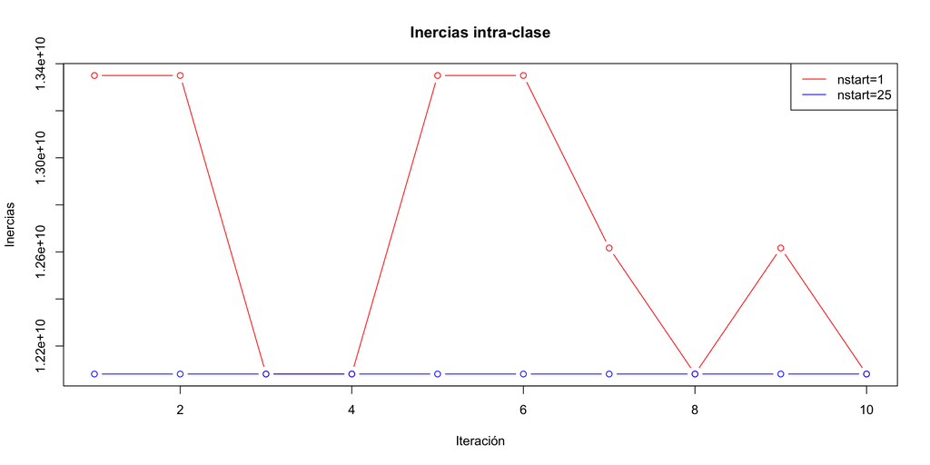

```r
plot(inercias1, type = "b", lwd = 1,col="red",main = "Inercias intra-clase",ylim=c(min(inercias1,inercias1),max(inercias1,inercias1)+10),xlab = "Iteración", ylab = "Inercias")
lines(inercias2, col = "blue", type = "b", lwd = 1)
legend("topright", legend = c("nstart=1", "nstart=25"), lty = 1,col = c("red", "blue"))
```

**Comparación del tiempo de ejecución para diferentes valores de nstart**

```r
library(bench)
mark("nstart = 1" = kmeans(datos, 4, nstart=1),
     "nstart = 10" = kmeans(datos, 4, nstart=10),
     "nstart = 100" = kmeans(datos, 4, nstart=100),
     check = F, relative = T, iterations = 3, filter_gc = F)
```

```
# A tibble: 3 x 6
  expression     min median `itr/sec` mem_alloc `gc/sec`
  <bch:expr>   <dbl>  <dbl>     <dbl>     <dbl>    <dbl>
1 nstart = 1     1      1       69.9       1        1.89
2 nstart = 10   11.3   11.8      6.00      4.60     1.14
3 nstart = 100  84.6   82.6      1        29.6      1
```

```r
setwd("~/Google Drive/MDCurso/Datos")
datos <- read.csv("creditcard.csv", header=TRUE, sep=",", dec=".",nrows = 1000, stringsAsFactors = TRUE)
datos$Class <- NULL
```

**Repaso del uso de lapply**

La función lapply recibe dos parámetros, una lista/vector **x** y un función, lo que hará es aplicar la función a cada uno de los items de la lista/vector **x**.

```r
cubos <- lapply(X = list(1,2,3,4,5), FUN = function(x) { return(x^3) })
cubos
```

```
[[1]]
[1] 1

[[2]]
[1] 8

[[3]]
[1] 27

[[4]]
[1] 64

[[5]]
[1] 125
```

**Convertir un for en un lapply**

**Versión con for**

```r
# nstart=Número de muestras aleatorias iniciales
# Repite 4 veces kmeans con nstart=25 con un "for", o sea código tipo estructurado
resultados<-list()
inercias<-rep(0,4)
for(k in 1:4) {
  resultados[[k]]<-kmeans(datos, 4, nstart=25)
  inercias[k]<-resultados[[k]]$tot.withinss
}
resultados<-resultados[[which.min(inercias)]]
inercias # Todos dan igual debido a que nstart=25
```

[output not shown]

**Versión con lapply**

```r
# El código debe ser transformado para usar lapply o sapply
# el cual repite 4 veces kmeans con nstart=25 código tipo funcional
resultados <- lapply(c(25,25,25,25), function(n.muestras) kmeans(datos, 4, nstart=n.muestras))
inercias <- sapply(resultados, function(resultados) resultados$tot.withinss)
resultados <- resultados[[which.min(inercias)]]
inercias
```

```
[1] 19115884 19115884 19115884 19115884
```

**Versión en paralelo con snow**

Antes de utilizar el paquete `snow` debemos establecer las siguientes configuraciones.

1. Cargar el paquete snow
2. Creación de los nodos (la cantidad de nodos no debe ser mayor a la cantidad de núcleos de la computadora).
3. Cargar paquetes en los nodos.
4. Exportar los datos a los nodos.
5. Ejecutar el proceso.
6. Cerrar los clusters.

```r
# Cargar el paquete snow
library(snow)
# Creación de los nodos
# Usaremos 4 "peones" en una máquina local usando un "socket"
peones <- parallel::detectCores()
cl <- makeCluster(peones, type = "SOCK")
# Carga de los paquetes en los nodos
ignore <- clusterEvalQ(cl, {library(MASS); NULL})
# Exportar los datos a los nodos
ignore <- clusterExport(cl, "datos")
```

**Ahora debemos modificar el código para correr en paralelo**

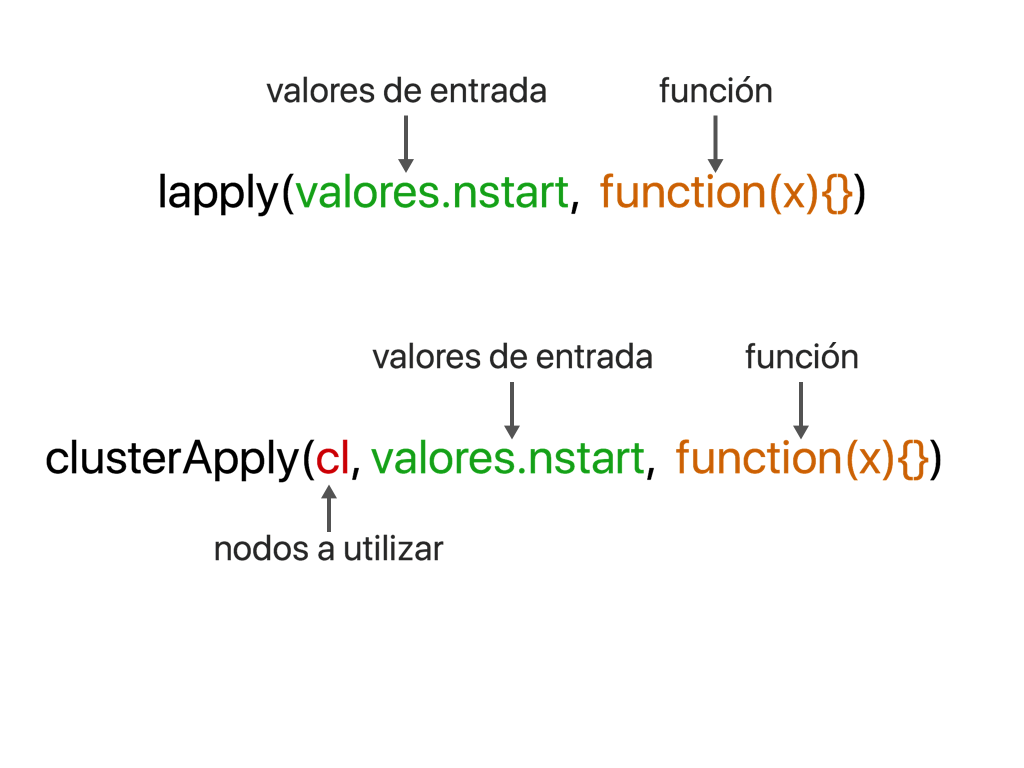

```r
resultados <- clusterApply(cl, c(25,25,25,25), function(n.muestras) kmeans(datos, 4,nstart=n.muestras))
inercias <- sapply(resultados, function(resultado) resultado$tot.withinss)
resultado <- resultados[[which.min(inercias)]]  # Se queda con el mejor resultado
inercias
```

```
[1] 22178701 22178701 22178701 19116079
```

```r
# Finaliza la computación paralela
stopCluster(cl)
```

**Comparando tiempos de ejecución lineal y paralelo**

```r
library(snow)
tiempo.usual<-system.time(resultados2 <- lapply(c(33,33,33,33),function(n.muestras) kmeans(x=datos, centers=4, nstart=n.muestras)))
inercia.intraclases <- sapply(resultados2, function(resultado) resultado$tot.withinss)
resultado.final <- resultados2[[which.min(inercia.intraclases)]]

## Versión Paralela
## En la versión paralela clusterApply sustituye a lapply
peones <- parallel::detectCores()
cl <- makeCluster(peones, type="SOCK")
ignore <- clusterEvalQ(cl, {library(MASS); NULL})
ignore <- clusterExport(cl, "datos")
tiempo.paralelo<-system.time(resultados <- clusterApply(cl, c(33,33,33,33),function(n.muestras) kmeans(Boston, 4,nstart=n.muestras)))
# El siguiente cálculo no vale la pena paralelizarlo pues es muy rápido
inercia.intraclases <- sapply(resultados, function(resultado) resultado$tot.withinss)
resultado.final <- resultados[[which.min(inercia.intraclases)]]
stopCluster(cl)

tiempo.usual
```

```
   user  system elapsed
   0.12    0.00    0.12
```

```r
tiempo.paralelo
```

```
   user  system elapsed
  0.001   0.001   0.013
```

```r
tiempo.usual<-system.time(resultados2 <- lapply(rep(33,40),function(n.muestras) kmeans(x=datos, centers=4, nstart=n.muestras)))
inercia.intraclases <- sapply(resultados2, function(resultado) resultado$tot.withinss)
resultado.final <- resultados2[[which.min(inercia.intraclases)]]

## Versión Paralela
library(snow)
peones <- parallel::detectCores()
cl <- makeCluster(peones, type="SOCK")
ignore <- clusterEvalQ(cl, {library(MASS); NULL})
ignore <- clusterExport(cl, "datos")
tiempo.paralelo<-system.time(resultados <- clusterApply(cl, rep(33,100),function(n.muestras) kmeans(datos, 4,nstart=n.muestras)))
# El siguiente cálculo no vale la pena paralelizarlo pues es muy rápido, aún en 100 iteraciones
inercia.intraclases <- sapply(resultados, function(resultado) resultado$tot.withinss)
resultado.final <- resultados[[which.min(inercia.intraclases)]]
stopCluster(cl)
tiempo.usual
```

```
   user  system elapsed
  1.193   0.069   1.262
```

```r
tiempo.paralelo
```

```
   user  system elapsed
  0.016   0.003   0.407
```

**Paralelizando el proceso de calibración de kmeans**

1. Carga de los datos

```r
setwd("~/Google Drive/MDCurso/Datos")
datos <- read.csv("UScrime.csv", header = TRUE, sep = ",", dec = ".", stringsAsFactors = TRUE)
datos$state <- as.factor(datos$state)
datos$fold <- as.factor(datos$fold)
str(datos)
```

```
'data.frame':   1994 obs. of  103 variables:
 $ state                : Factor w/ 46 levels "1","2","4","5",..: 6 43 19 26 34 5 35 5 16 23 ...
 $ fold                 : Factor w/ 10 levels "1","2","3","4",..: 1 1 1 1 1 1 1 1 1 1 ...
 $ population           : num  0.19 0 0 0.04 0.01 0.02 0.01 0.01 0.03 0.01 ...
 $ householdsize        : num  0.33 0.16 0.42 0.77 0.55 0.28 0.39 0.74 0.34 0.4 ...
 $ racepctblack         : num  0.02 0.12 0.49 1 0.02 0.06 0 0.03 0.2 0.06 ...
 $ racePctWhite         : num  0.9 0.74 0.56 0.08 0.95 0.54 0.98 0.46 0.84 0.87 ...
 $ racePctAsian         : num  0.12 0.45 0.17 0.12 0.09 1 0.06 0.2 0.02 0.3 ...
 $ racePctHisp          : num  0.17 0.07 0.04 0.1 0.05 0.25 0.02 1 0 0.03 ...
 $ agePct12t21          : num  0.34 0.26 0.39 0.51 0.38 0.31 0.3 0.52 0.38 0.9 ...
 $ agePct12t29          : num  0.47 0.59 0.47 0.5 0.38 0.48 0.37 0.55 0.45 0.82 ...
 $ agePct16t24          : num  0.29 0.35 0.28 0.34 0.23 0.27 0.23 0.36 0.28 0.8 ...
 $ agePct65up           : num  0.32 0.27 0.32 0.21 0.36 0.37 0.6 0.35 0.48 0.39 ...
 $ numbUrban            : num  0.2 0.02 0 0.06 0.02 0.04 0.02 0 0.04 0.02 ...
 $ pctUrban             : num  1 1 0 1 0.9 1 0.81 0 1 1 ...
```

[output cut: 86 more lines]

```r
grupos1 <- kmeans(x = datos, centers = 7, iter.max = 10,
                  nstart = 1, algorithm = "Hartigan-Wong")
grupos1$betweenss
```

```
[1] 528596.2
```

```r
grupos2 <- kmeans(x = datos, centers = 7, iter.max = 10,
                  nstart = 1, algorithm = "Lloyd")
grupos2$betweenss
```

```
[1] 523729.4
```

```r
grupos3 <- kmeans(x = datos, centers = 7, iter.max = 10,
                  nstart = 1, algorithm = "Forgy")
grupos3$betweenss
```

```
[1] 523881.8
```

```r
grupos4 <- kmeans(x = datos, centers = 7, iter.max = 10,
                  nstart = 1, algorithm = "MacQueen")
grupos4$betweenss
```

```
[1] 527767.2
```

1. Construir un conjunto de parámetros

```r
parametros <- c("Hartigan-Wong","Lloyd","Forgy","MacQueen")
```

2. Generamos un modelo para cada una de los conjuntos de parámetros

```r
grupos <- lapply(parametros, function(algoritmos) {
  kmeans(x = datos, centers = 7, iter.max = 1000,
         nstart = 250, algorithm = algoritmos)
})
# imprimimos las inercias
lapply(grupos, function(gr) print(gr$betweenss))
```

```
[1] 529470.2
[1] 529470.2
[1] 529470.2
[1] 529470.2
```

```
[[1]]
[1] 529470.2

[[2]]
[1] 529470.2

[[3]]
[1] 529470.2

[[4]]
[1] 529470.2
```

3. Configuraciones para snow

```r
# Cargar el paquete snow
library(snow)
# Creación de los nodos
peones <- parallel::detectCores()
cl <- makeCluster(peones, type = "SOCK")
# Carga de los paquetes en los nodos
ignore <- clusterEvalQ(cl, {library(MASS); NULL})
# Exportar los datos a los nodos
ignore <- clusterExport(cl, "datos")
```

3. Generamos un modelo en paralelo para cada una de los conjuntos de parámetros

```r
grupos <- clusterApply(cl, parametros, function(algoritmos) {
  kmeans(x = datos, centers = 7, iter.max = 10,
         nstart = 1, algorithm = algoritmos)
})
# imprimimos las inercias
lapply(grupos, function(gr) print(gr$betweenss))
```

```
[1] 528998.1
[1] 528790.8
[1] 523081.7
[1] 526189.9
```

```
[[1]]
[1] 528998.1

[[2]]
[1] 528790.8

[[3]]
[1] 523081.7

[[4]]
[1] 526189.9
```

4. Detener los nodos

```r
stopCluster(cl)
```

**Comparativa de tiempos entre versión sequencial y paralela**

```r
# Cargar el paquete snow
library(snow)
# Creación de los nodos
peones <- parallel::detectCores()
cl <- makeCluster(peones, type = "SOCK")
# Carga de los paquetes en los nodos
ignore <- clusterEvalQ(cl, {library(MASS); NULL})
# Exportar los datos a los nodos
ignore <- clusterExport(cl, "datos")
```

```r
mark("sequencial" = { # No es paralelo porque no está en "cl" ni usa clusterApply
  lapply(parametros, function(algoritmos) {
  kmeans(x = datos, centers = 7, iter.max = 1000,
         nstart = 250, algorithm = algoritmos)})
},
"paralelo" = { # Esta sí es paralela
  clusterApply(cl, parametros, function(algoritmos) {
  kmeans(x = datos, centers = 7, iter.max = 1000,
         nstart = 250, algorithm = algoritmos)})
}, iterations = 3, check = F)
```

```
# A tibble: 2 x 6
  expression      min   median `itr/sec` mem_alloc `gc/sec`
  <bch:expr> <bch:tm> <bch:tm>     <dbl> <bch:byt>    <dbl>
1 sequencial   14.73s   14.93s    0.0672    1.65GB     4.14
2 paralelo      5.25s    5.35s    0.186    96.19KB     0
```

**Cerrar nodos**

```r
stopCluster(cl)
```